# Data Visualization in R

PhD Plus - 2020

## About ggplot2

- Developed by Hadley Wickham in 2005.
- Implements the graphics scheme described in the book *The Grammar of Graphics* by Leland Wilkinson.
- Uses a standardized system of syntax that makes it easy(-ish) to learn.
- It does not do 3D or interactive graphics.

## The Grammar of Graphics

The *Grammar of Graphics* boiled down to 5 bullets, courtesy of Wickham (2016, p. 4):

- a statistical graphic is a mapping from data to **aes**thetic attributes (location, color, shape, size) of **geom**etric objects (points, lines, bars).
- the geometric objects are drawn in a specific **coord**inate system.
- **scale**s control the mapping from data to aesthetics and provide tools to read the plot (ie, axes and legends).
- the plot may also contain **stat**istical transformations of the data (means, medians, bins of data, trend lines).
- **facet**ing can be used to generate the same plot for different subsets of the data.

## Basic ggplot2 syntax

**Specify data, aesthetics and geometric shapes**

`ggplot(data, aes(x=, y=, color=, shape=, size=)) +`  
`geom_point()`, or `geom_histogram()`, or `geom_boxplot()`, etc.

- This combination is very effective for exploratory graphs.
- The data must be a data frame.
- The `aes()` function maps columns of the data frame to aesthetic properties of geometric shapes to be plotted.
- `ggplot()` defines the plot; the `geoms` show the data; each component is added with `+`
- Some examples should make this clear

## The Albemarle county homes data

We’ll demonstrate `ggplot2` using the Albemarle County real estate data, which was downloaded from Office of Geographic Data Services.

Some variables of interest:

- total value of home (totalvalue)
- finished square feet (finsqft)
- high school district in which house is located (hsdistrict)

Note: the following examples use a sample of the homes data.

## scatter plot colored by high school district

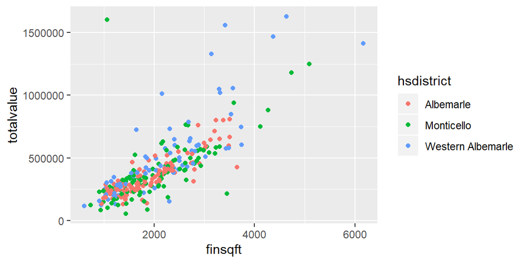

```r
library(ggplot2) # or library(tidyverse)
ggplot(homes, aes(x=finsqft, y=totalvalue,
                 color=hsdistrict)) + geom_point()
```

## add multiple geoms (points and smooth line)

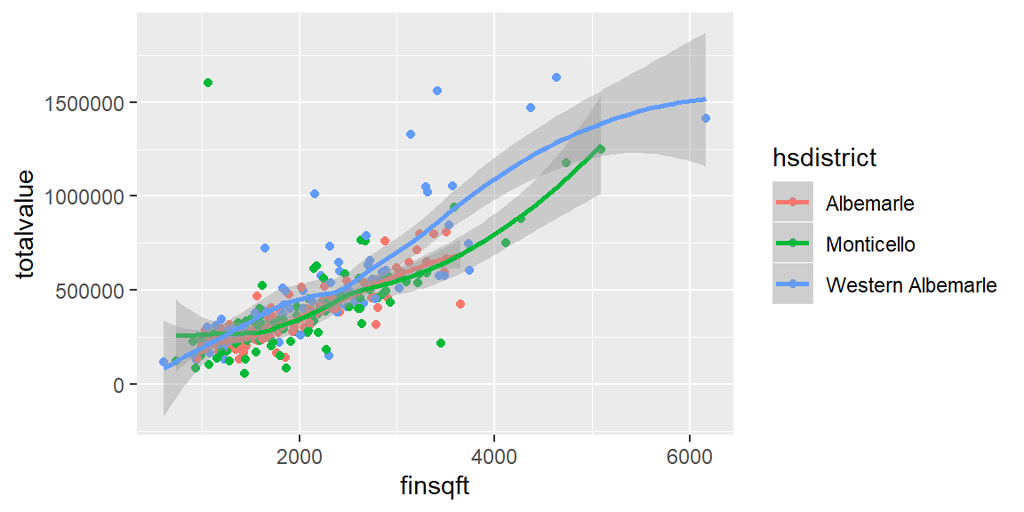

```r
ggplot(homes, aes(x=finsqft, y=totalvalue,
                  color=hsdistrict)) + geom_point() +
  geom_smooth()
```

## Moving beyond `ggplot` + `geoms`

- A natural next step in exploratory graphing is to create plots of subsets of data. These are called facets in ggplot2.
- Use `facet_wrap()` if you want to facet by one variable and have `ggplot2` control the layout. Example:
  - `+ facet_wrap( ~ var)`
- Use `facet_grid()` if you want to facet by one and/or two variables and control layout yourself.

Examples:  
+ `facet_grid(. ~ var1)` - facets in columns  
+ `facet_grid(var1 ~ .)` - facets in rows  
+ `facet_grid(var1 ~ var2)` - facets in rows and columns

## `facet_wrap`

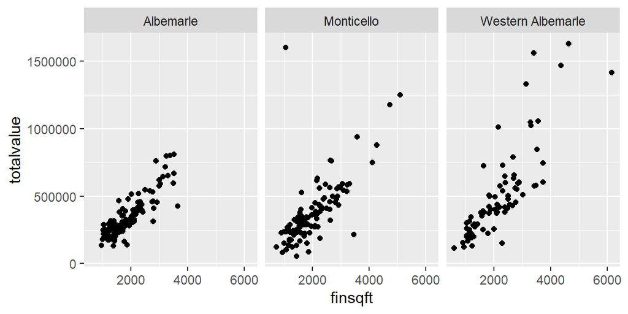

```r
ggplot(homes, aes(x=finsqft, y=totalvalue)) +
  geom_point() + facet_wrap(~ hsdistrict)
```

## `facet_grid` (histograms)

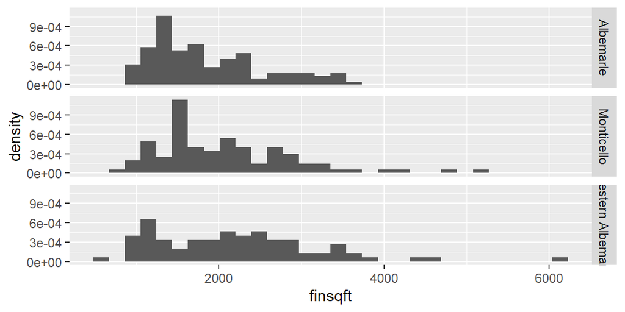

```r
ggplot(homes, aes(x=finsqft, y = stat(density))) +
  geom_histogram() + facet_grid(hsdistrict ~ .)
```

## Modifying the coordinate system

- `coord_cartesian` allows us to zoom in on a plot, as if using a magnifying glass
- `coord_fixed` allows us to control “aspect ratio”
- `coord_flip` allows us to flip the x and y axis

## zoom in on plot

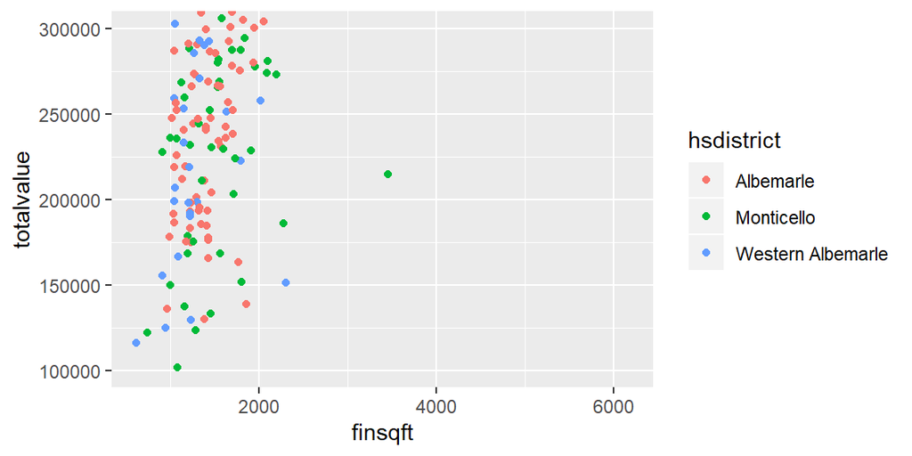

```r
ggplot(homes, aes(x=finsqft, y=totalvalue,
                 color=hsdistrict)) + geom_point() +
  coord_cartesian(ylim = c(1e5, 3e5))
```

## Customizing scales

- Scales control the mapping from data to aesthetics and provide tools to read the plot (ie, axes and legends).
- Every aesthetic has a default scale. To modify a scale, use a `scale` function.
- All scale functions have a common naming scheme:  
  `scale` `_` name of aesthetic `_` name of scale
- Examples: `scale_y_continuous`, `scale_color_discrete`, `scale_fill_manual`
- Heads up: The documentation for `ggplot2` scale functions will frequently use functions from the `scales` package (also by Wickham)!

## update scales for x- and y-axis

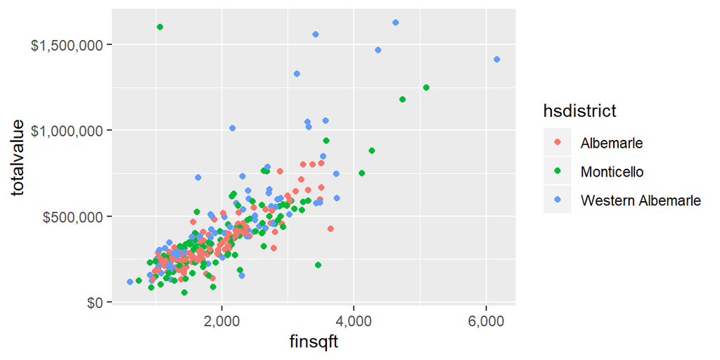

```r
ggplot(homes, aes(x=finsqft, y=totalvalue,
                 color=hsdistrict)) + geom_point() +
  scale_y_continuous(labels = scales::dollar) +
  scale_x_continuous(labels = scales::comma)
```

## Update themes and labels

- The default ggplot2 theme is excellent. It follows the advice of several landmark papers regarding statistics and visual perception. (Wickham 2016, p. 176)
- However you can change the theme using ggplot2’s themeing system. To date, there are seven built-in themes: `theme_gray` (*default*), `theme_bw`, `theme_linedraw`, `theme_light`, `theme_dark`, `theme_minimal`, `theme_classic`
- You can also update axis labels and titles using the `labs` function.

## change theme

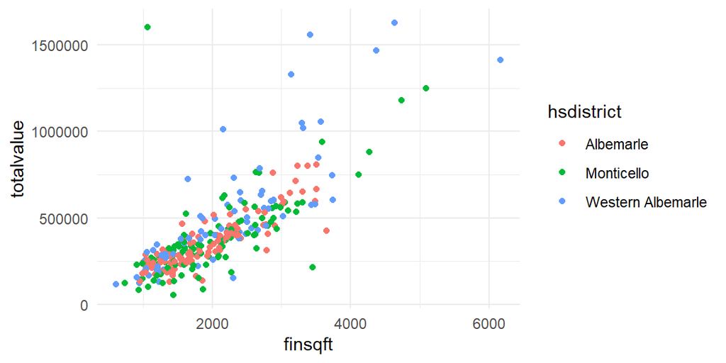

```r
ggplot(homes, aes(x=finsqft, y=totalvalue,
                 color = hsdistrict)) + geom_point() +
  theme_minimal()
```

## update labels

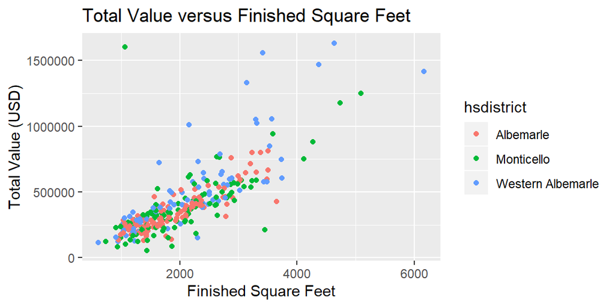

```r
ggplot(homes, aes(x=finsqft, y=totalvalue,
                 color = hsdistrict)) + geom_point() +
  labs(title="Total Value versus Finished Square Feet",
       x="Finished Square Feet", y="Total Value (USD)")
```

## ggplot2 - some tips

- Can do a lot with `ggplot(data, aes()) + geom`!
- Data must be a data frame (not a matrix or collection of vectors)
- The `ggplot2` documentation has many good examples
- Prepare to invest some time if you want master ggplot2; [the RStudio ggplot2 cheat sheet](https://rstudio.com/wp-content/uploads/2016/11/ggplot2-cheatsheet-2.1.pdf) can help.

Let’s go to R!

## References

- Chang, W. (2013), *R Graphics Cookbook*, O’Reilly.
- Wickham, H. (2016), *ggplot2: Elegant Graphics for Data Analysis* (2nd ed), Springer.
- Wickham, H. and Grolemund G. (2017), *R for Data Science*. O’Reilly. http://r4ds.had.co.nz/

## Web sites

**ggplot2 cheat sheet**  
https://github.com/rstudio/cheatsheets/raw/master/data-visualization-2.1.pdf

**Cookbook for R - Graphs**  
http://www.cookbook-r.com/Graphs/

**Official ggplot2 web site**  
https://ggplot2.tidyverse.org/

**More on plotly**  
https://plotly-r.com